# Cyclistic proyect

Aaron

2023-08-02

Preparo el ambiente

```r
library(tidyverse)
```

## Preparar

Descargo y extraigo los datos internos de la ‘empresa’ [link](https://divvy-tripdata.s3.amazonaws.com/index.html) de todo el 2022

```r
tripdata_01 <- read_csv("tripdata/202201-divvy-tripdata.csv")
tripdata_02 <- read_csv("tripdata/202202-divvy-tripdata.csv")
tripdata_03 <- read_csv("tripdata/202203-divvy-tripdata.csv")
tripdata_04 <- read_csv("tripdata/202204-divvy-tripdata.csv")
tripdata_05 <- read_csv("tripdata/202205-divvy-tripdata.csv")
tripdata_06 <- read_csv("tripdata/202206-divvy-tripdata.csv")
tripdata_07 <- read_csv("tripdata/202207-divvy-tripdata.csv")
tripdata_08 <- read_csv("tripdata/202208-divvy-tripdata.csv")
tripdata_09 <- read_csv("tripdata/202209-divvy-tripdata.csv")
tripdata_10 <- read_csv("tripdata/202210-divvy-tripdata.csv")
tripdata_11 <- read_csv("tripdata/202211-divvy-tripdata.csv")
tripdata_12 <- read_csv("tripdata/202212-divvy-tripdata.csv")
```

Veamos su estuctura

```r
head(tripdata_01)
```

```
## # A tibble: 6 × 13
##   ride_id          rideable_type started_at          ended_at
##   <chr>            <chr>         <dttm>              <dttm>
## 1 C2F7DD78E82EC875 electric_bike 2022-01-13 11:59:47 2022-01-13 12:02:44
## 2 A6CF8980A652D272 electric_bike 2022-01-10 08:41:56 2022-01-10 08:46:17
## 3 BD0F91DFF741C66D classic_bike  2022-01-25 04:53:40 2022-01-25 04:58:01
## 4 CBB80ED419105406 classic_bike  2022-01-04 00:18:04 2022-01-04 00:33:00
## 5 DDC963BFDDA51EEA classic_bike  2022-01-20 01:31:10 2022-01-20 01:37:12
## 6 A39C6F6CC0586C0B classic_bike  2022-01-11 18:48:09 2022-01-11 18:51:31
## # ℹ 9 more variables: start_station_name <chr>, start_station_id <chr>,
## #   end_station_name <chr>, end_station_id <chr>, start_lat <dbl>,
## #   start_lng <dbl>, end_lat <dbl>, end_lng <dbl>, member_casual <chr>
```

```r
str(tripdata_01)
```

```
## spc_tbl_ [103,770 × 13] (S3: spec_tbl_df/tbl_df/tbl/data.frame)
##  $ ride_id           : chr [1:103770] "C2F7DD78E82EC875" "A6CF8980A652D272" "BD0F91DFF741C66D" "CBB80ED419105406" ...
##  $ rideable_type     : chr [1:103770] "electric_bike" "electric_bike" "classic_bike" "classic_bike" ...
##  $ started_at        : POSIXct[1:103770], format: "2022-01-13 11:59:47" "2022-01-10 08:41:56" ...
##  $ ended_at          : POSIXct[1:103770], format: "2022-01-13 12:02:44" "2022-01-10 08:46:17" ...
##  $ start_station_name: chr [1:103770] "Glenwood Ave & Touhy Ave" "Glenwood Ave & Touhy Ave" "Sheffield Ave & Fullerton Ave" "Clark St & Bryn Mawr Ave" ...
##  $ start_station_id  : chr [1:103770] "525" "525" "TA1306000016" "KA1504000151" ...
##  $ end_station_name  : chr [1:103770] "Clark St & Touhy Ave" "Clark St & Touhy Ave" "Greenview Ave & Fullerton Ave" "Paulina St & Montrose Ave" ...
##  $ end_station_id    : chr [1:103770] "RP-007" "RP-007" "TA1307000001" "TA1309000021" ...
##  $ start_lat         : num [1:103770] 42 42 41.9 42 41.9 ...
##  $ start_lng         : num [1:103770] -87.7 -87.7 -87.7 -87.7 -87.6 ...
##  $ end_lat           : num [1:103770] 42 42 41.9 42 41.9 ...
##  $ end_lng           : num [1:103770] -87.7 -87.7 -87.7 -87.7 -87.6 ...
##  $ member_casual     : chr [1:103770] "casual" "casual" "member" "casual" ...
##  - attr(*, "spec")=
##   .. cols(
##   ..   ride_id = col_character(),
##   ..   rideable_type = col_character(),
##   ..   started_at = col_datetime(format = ""),
##   ..   ended_at = col_datetime(format = ""),
##   ..   start_station_name = col_character(),
##   ..   start_station_id = col_character(),
##   ..   end_station_name = col_character(),
##   ..   end_station_id = col_character(),
##   ..   start_lat = col_double(),
##   ..   start_lng = col_double(),
##   ..   end_lat = col_double(),
##   ..   end_lng = col_double(),
##   ..   member_casual = col_character()
##   .. )
##  - attr(*, "problems")=<externalptr>
```

## Procesar

Como los datos tienen la misma estructura, las fusiono en un solo archivo

```r
tripdata <- bind_rows(tripdata_01, tripdata_02, tripdata_03, tripdata_04, tripdata_05, tripdata_06, tripdata_07, tripdata_08, tripdata_09, tripdata_10, tripdata_11, tripdata_12)
```

Limpio el ambiente global de los datos que ya no necesito

```r
rm(tripdata_01, tripdata_02, tripdata_03, tripdata_04, tripdata_05, tripdata_06, tripdata_07, tripdata_08, tripdata_09, tripdata_10, tripdata_11, tripdata_12)
```

Creo las siguiente variables: `ride_length, day_of_week y month_of_year`

```r
tripdata <- tripdata %>% mutate(ride_length = abs(round(as.numeric(difftime(ended_at, started_at, units = "mins")),3)),
                                day_of_week = wday(started_at),
                                month_of_year = month(started_at))
```

Filtro las variables que voy a usar

```r
tripdata <- tripdata %>%
  select(ride_id,
         started_at,
         start_station_name,
         end_station_name,
         member_casual,
         ride_length,
         day_of_week,
         month_of_year) %>%
  arrange(started_at)
```

Veamos como quedo

```r
str(tripdata)
```

```
## tibble [5,667,717 × 8] (S3: tbl_df/tbl/data.frame)
##  $ ride_id           : chr [1:5667717] "98D355D9A9852BE9" "04706CA7F5BD25EE" "42178E850B92597A" "6B93C46E8F5B114C" ...
##  $ started_at        : POSIXct[1:5667717], format: "2022-01-01 00:00:05" "2022-01-01 00:01:00" ...
##  $ start_station_name: chr [1:5667717] "Michigan Ave & 8th St" "Broadway & Waveland Ave" "Clark St & Ida B Wells Dr" "Michigan Ave & 8th St" ...
##  $ end_station_name  : chr [1:5667717] "Michigan Ave & 8th St" "Broadway & Barry Ave" "Clark St & Ida B Wells Dr" "Michigan Ave & 8th St" ...
##  $ member_casual     : chr [1:5667717] "casual" "casual" "casual" "casual" ...
##  $ ride_length       : num [1:5667717] 1.72 3.65 30.97 28.88 28.48 ...
##  $ day_of_week       : num [1:5667717] 7 7 7 7 7 7 7 7 7 7 ...
##  $ month_of_year     : num [1:5667717] 1 1 1 1 1 1 1 1 1 1 ...
```

## Analizar

Veamos la promedio general de ride_length

```r
tripdata %>%
  summarize(average_ride_length = mean(ride_length))
```

```
## # A tibble: 1 × 1
##   average_ride_length
##                 <dbl>
## 1                19.4
```

Ahora, el maximo de ride_length

```r
tripdata %>%
  summarize(max_ride_length = max(ride_length))
```

```
## # A tibble: 1 × 1
##   max_ride_length
##             <dbl>
## 1          41387.
```

Calculemos el modo de day_of_week

```r
days <- c("Sunday", "Monday", "Tuesday", "Wednesday", "Thursday", "Friday", "Saturday")
days[(tripdata %>%
        group_by(day_of_week) %>%
        count(day_of_week) %>%
        arrange(n))$day_of_week[7]]
```

```
## [1] "Saturday"
```

Conclusion: el sabado es el dia que mas uso le dan los usuarios a las bicicletas.

Comparemos el promedio de ride_length para clientes miembros y casuales en general

```r
tripdata %>%
  group_by(member_casual) %>%
  summarise(average_ride_length = mean(ride_length))
```

```
## # A tibble: 2 × 2
##   member_casual average_ride_length
##   <chr>                       <dbl>
## 1 casual                       29.1
## 2 member                       12.7
```

Comparemos el promedio de ride_length por dia de la semana (day_of_week)

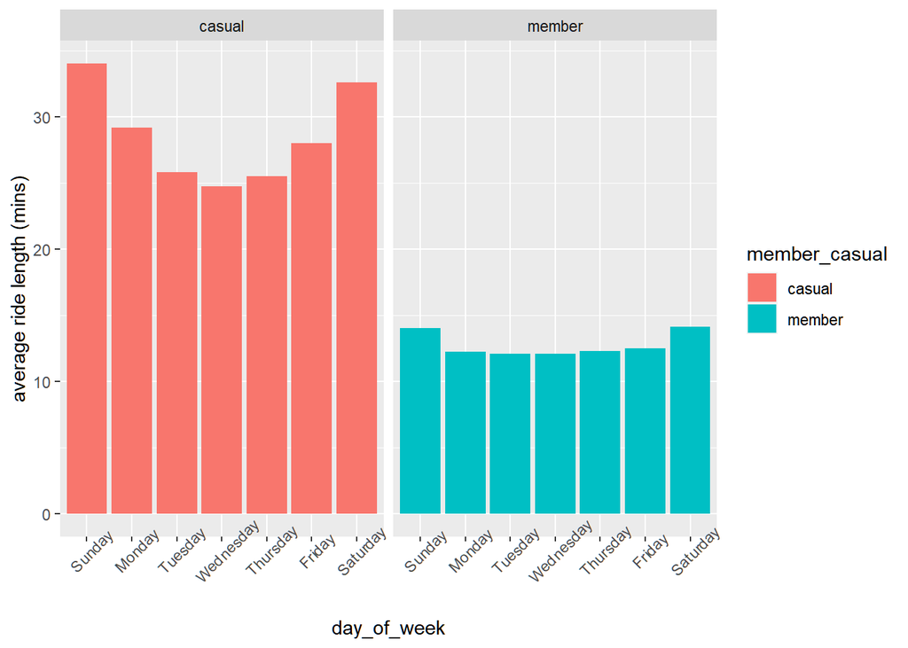

```r
average_trip <- tripdata %>%
  group_by(day_of_week, member_casual) %>%
  summarise(average = mean(ride_length)) %>%
  arrange(day_of_week)

ggplot(data = average_trip) +
  geom_col(mapping = aes(x = day_of_week, y = average, fill = member_casual)) +
  facet_wrap(~member_casual) +
  labs(y = "average ride length (mins)") +
  scale_x_discrete(limits = factor(1:7), labels = days) +
  theme(axis.text.x = element_text(angle = 45))
```

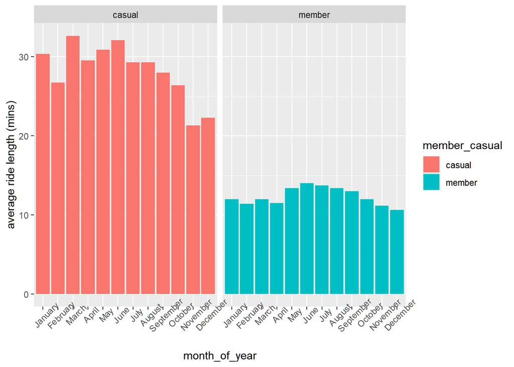

```r
average_trip <- tripdata %>%
  group_by(month_of_year, member_casual) %>%
  summarise(average = mean(ride_length)) %>%
  arrange(month_of_year)

months <- c("January", "February", "March", "April", "May", "June", "July", "August", "September", "October", "November", "December")

ggplot(data = average_trip) +
  geom_col(mapping = aes(x = month_of_year, y = average, fill = member_casual)) +
  facet_wrap(~member_casual) +
  labs(y = "average ride length (mins)") +
  scale_x_discrete(limits = factor(1:12), labels = months) +
  theme(axis.text.x = element_text(angle = 45))
```

Comparemos la cantidad de viajes total por dia de la semana para miembros y casuales

Primero en general

```r
tripdata %>%
  group_by(day_of_week) %>%
  count(day_of_week) %>%
  arrange(day_of_week) %>%
  rename("cant_trips" = n)
```

```
## # A tibble: 7 × 2
## # Groups:   day_of_week [7]
##   day_of_week cant_trips
##         <dbl>      <int>
## 1           1     776259
## 2           2     751014
## 3           3     782372
## 4           4     798223
## 5           5     841591
## 6           6     801787
## 7           7     916471
```

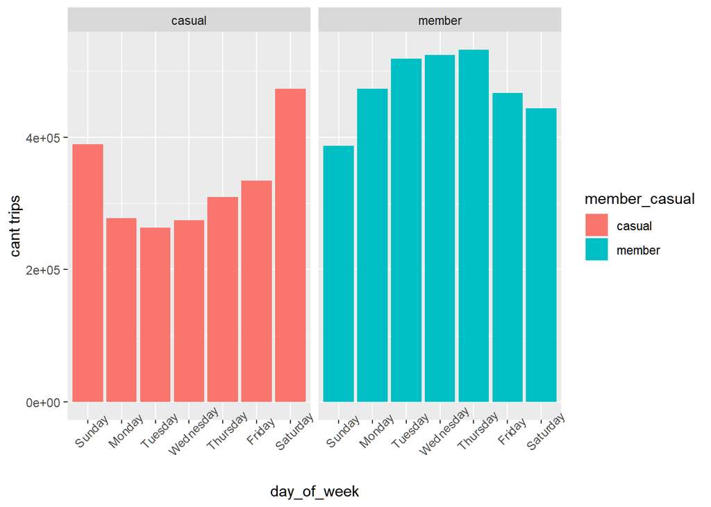

```r
cant_trips <- tripdata %>%
  group_by(day_of_week, member_casual) %>%
  count(day_of_week) %>%
  arrange(day_of_week)

ggplot(data = cant_trips) +
  geom_col(mapping = aes(x = day_of_week, y = n, fill = member_casual)) +
  facet_wrap(~member_casual) +
  labs(y = "cant trips") +
  scale_x_discrete(limits = factor(1:7), labels = days) +
  theme(axis.text.x = element_text(angle = 45))
```

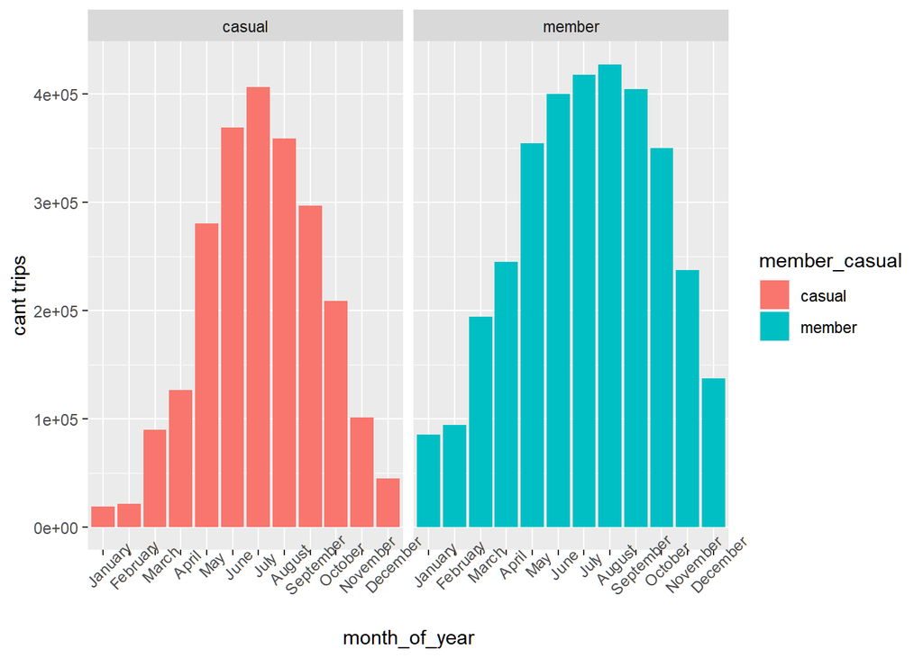

```r
cant_trips <- tripdata %>%
  group_by(month_of_year, member_casual) %>%
  count(month_of_year) %>%
  arrange(month_of_year)

ggplot(data = cant_trips) +
  geom_col(mapping = aes(x = month_of_year, y = n, fill = member_casual)) +
  facet_wrap(~member_casual) +
  labs(y = "cant trips") +
  scale_x_discrete(limits = factor(1:12), labels = months) +
  theme(axis.text.x = element_text(angle = 45))
```

## Recomendaciones

- Crear mas paradas de bicletas para que los usuarios casuales se vean mas motivados a usar las bicicletas regularmente en viajes mas cortos